# Forecasting Total Supplier Services Using ARIMA and Prophet

## Final ARIMA Model Summary

The selected ARIMA model is **ARIMA(1, 1, 3)**, indicating:

- One autoregressive term (AR=1).
- First-order differencing to achieve stationarity (I=1).
- Three moving average terms (MA=3) to capture the residual structure.

### Model Parameters

| **Parameter** | **Coefficient** | **Std. Error** | **z-Statistic** | **P-Value** | **Confidence Interval (95%)** |
| --- | --- | --- | --- | --- | --- |
| **ar.L1** | -0.7555 | 0.005 | -143.538 | 0.000 | [-0.766, -0.745] |
| **ma.L1** | -0.1856 | 0.005 | -35.533 | 0.000 | [-0.196, -0.175] |
| **ma.L2** | -0.7375 | 0.005 | -159.007 | 0.000 | [-0.747, -0.728] |
| **ma.L3** | 0.0295 | 0.000 | 60.114 | 0.000 | [0.029, 0.030] |
| **sigma²** | 8.277e+11 | 1.5e-14 | 5.53e+25 | 0.000 | [8.28e+11, 8.28e+11] |

### Model Evaluation

| **Metric** | **Value** | **Description** |
| --- | --- | --- |
| **Log Likelihood** | -4,235,732.419 | Indicates the likelihood of the model given the data. Higher is better. |
| **AIC (Akaike)** | 8,471,474.839 | Balances model fit and complexity; lower values are preferred. |
| **BIC (Bayesian)** | 8,471,527.557 | Penalizes complexity more heavily than AIC. |
| **Heteroskedasticity (H)** | 1.37 | Indicates non-constant variance; value > 1 suggests heteroskedasticity. |
| **Ljung-Box (L1) (Q)** | 0.01 (p=0.92) | Tests residual autocorrelation. High p-value (> 0.05) indicates no significant autocorrelation. |
| **Jarque-Bera (JB)** | 2.94e+11 (p=0.00) | Tests for normality of residuals. Low p-value (< 0.05) indicates significant deviation. |

### Observations

1. **Good Fit with Overfitting Risk**:
   - The ARIMA model fits well on the training data but exhibits signs of overfitting, reflected in the higher RMSE for the test dataset.
2. **Residual Diagnostics**:
   - Residuals show no significant autocorrelation (high p-value for Ljung-Box), but the Jarque-Bera test indicates non-normality in residuals.
3. **Forecasting Limitations**:
   - High heteroskedasticity and non-normal residuals may impact the reliability of long-term forecasts.

```
[]
```

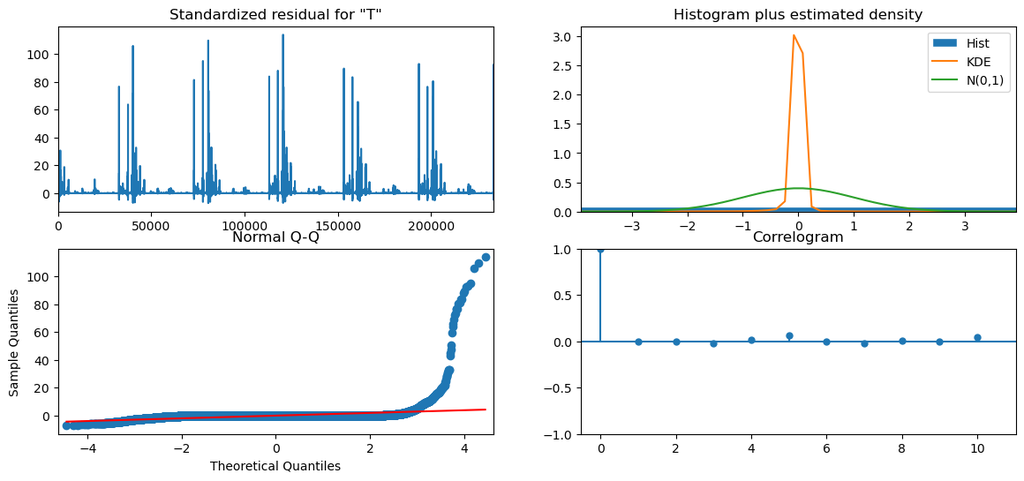

```python
# fitted model plot diagnostics
fitted_model.plot_diagnostics(figsize=(14, 6))
# Show the plot
plt.plot()
```

### Residual Diagnostic Analysis

- **Standardized Residuals (Top Left):** The residuals fluctuate around zero but exhibit spikes, indicating possible outliers or non-random behavior at certain intervals.
- **Histogram (Top Right):** The residuals deviate from the normal distribution (green line), with a sharp peak, suggesting non-normality.
- **Normal Q-Q Plot (Bottom Left):** The residuals show significant deviations from the red line, particularly at the tails, further indicating non-normality and the presence of outliers.
- **Correlogram (Bottom Right):** Most lags fall within the confidence bounds, suggesting that the residuals exhibit weak autocorrelation, which is desirable for a good model fit.

### Conclusion

While the model captures most patterns, the residuals' non-normality and occasional spikes suggest potential issues such as outliers or unmodeled complexity in the data. Model refinement (e.g., robust transformations or including additional predictors) may improve results.